# Lecture 7: Boleean variables and if/else statements

In this class we will:

- Introduce **boolean** objects
- Test different categories of expressions with text and numbers
- Learn how to use if/elif/else statements to write code that executes different commands based on conditions

Let's start by importing the modules we'll need for this notebook.

```python
import numpy as np
import matplotlib.pyplot as plt
```

## I. Boolean objects

Out of the many built-in objects in Python, two of them are of "Boolean" type. These are the objects `True` and `False`

These should not be confused with the strings "True" and "False"

```python
# Boolean Objects
print(type(True))
print(type(False))

print()

# Adding quotes results in string objects
print(type("True"))
print(type('False'))
```

```
<class 'bool'>
<class 'bool'>

<class 'str'>
<class 'str'>
```

What is a Boolean object? It is just an object that can take one of two possible values. In this case, `True` and `False`.

We can assign these values to variables directly:

```python
x = True

my_statement = False
```

But more commonly, we obtain Boolean values in other, indirect ways.

## II. Comparison Operators

- One of the most common ways Boolean objects show up is in the use of **comparison operators**.
- These are operators used to compare two values, and evaluate to either `True` or `False`.
- There are six basic comparison operators. The first four are:
  - `>` - Greater than
  - `<` - Less than
  - `>=` - Greater than or equal to
  - `<=` - Less than or equal to

```python
# Test if one number is greater than the other
print(5 > 3)

print(3 > 9)

print(4 + 3 > 6)
```

```
True
False
True
```

```python
# Test if one number is less than the other
print(0 < -2.5)

print(1 < 1.01)

print(30/10 < 1)
```

```
False
True
False
```

```python
# Test if one number is greater that or equal to the other
print(10 >= 1)

print(8 >= 50)

print(2**3 >= 10)
```

```
True
False
False
```

```python
# Greater than OR equal to!
print(5 > 5) # this is false
print(5 >= 5) # this is true, since 5 equals 5
```

```
False
True
```

```python
# Test if one number is less than or equal to the other
print(10 <= 5 + 5)

print(8 <= 8.1)

print(2**3 <= 2*3)
```

```
True
True
False
```

Two more basic comparison operators

- `==` - Equal
- `!=` - Not equal

**Warning**: Do not confuse the assignment operator `=` with the comparison operator that tests for equality `==`

```python
# Does 5*3 equal 15? (Yes)
print(5*3 == 15)

# Does 3 - 2 equal 7? (No)
print(3 - 2 == 7)
```

```
True
False
```

```python
# Is 5*3 + 1 different from 20? (yes)
print(5*3 + 1 != 20)

# Is 10/5 different from 2? (no)
print(10/5 != 2)
```

```
True
False
```

In many cases, we use a comparison operator with one or more variables

```python
a = 7
b = 3
c = 5

print(a*b > c**2)


x = np.sin(12*np.pi/7)
print(x < 0)
```

```
False
True
```

## III. Strings and Lists

- The "equals to" comparison and "not equals to" comparison extend naturally to strings and lists
- If every character in a string matches another string **exactly**, then they are equal.
- If every element in a list matches **every** element in another list, then they are equal. **Order of the elements matters**

```python
x = "Hello World!"
y = "Hello World !"

print(x == "Hello World!")
print(y == "Hello World!")

print(x != y)

print('ab' == 'ba')
```

```
True
False
True
False
```

```python
list_1 = ["blue", "red", "green"]
list_2 = ["blue", "red", "green"]
list_3 = ["red", "green", "blue"]
list_4 = ["red", "green", "blue", "violet"]

print(list_1 == list_2)
print(list_1 == list_3) # False: different ordering
print(list_3 == list_4) # False: different number of elements
print(list_3 != list_4) # True
```

```
True
False
False
True
```

```python
list_1 = [1, 2, 3]
list_2 = [1, 2, 3]
list_3 = [2, 3, 1]
list_4 = [2, 3, 1, 4]

print(list_1 == list_2)
print(list_1 == list_3) # False: different ordering
print(list_3 == list_4) # False: different number of elements
print(list_3 != list_4) # True
```

```
True
False
False
True
```

The other comparison operators `<`, `>`, `<=`, and `>=` can also be used for strings and lists. However, the behavior is not obvious. See the exercises for more.

## IV. NumPy Arrays

When comparing Numpy arrays, a separate Boolean expression is returned for **each element**

```python
vec_a = np.array([1,2,3])
vec_b = np.array([1,2,4])

print(vec_a == vec_b)

vec_c = np.array([10, 5, 3])
vec_d = np.array([20, 10, 8])
print(vec_c >= vec_d)
```

```
[ True  True False]
[False False False]
```

## V. The `in` keyword

This keyword allows us to test whether

- A character appears in a string
- An object appears in a list
- A number appears in a numpy array

```python
# The first way to use the "in" command is to check whether a word is contained
# in a sentence. This can be useful if you're trying to search for patterns

sentence = "The Federal Reserve makes forecasts about many economic outcomes"


keyword = "economic"
print(keyword in sentence)

keyword = "bank"
print(keyword in sentence)

search_word = "Federal"
print(search_word in sentence)

important_word = "federal"
print(important_word in sentence)

print("F" in sentence)
```

```
True
False
True
False
True
```

```python
# Use the condition "in" to test whether a word is part of a list
# when the right-hand size is a list "word in list" will search for an exact match

current_month  = "February"

list_summer_months = ["June","July","August"]

print(current_month in list_summer_months)
print('June' in list_summer_months)
print("J" in list_summer_months)

print()

print("After adding a new element to the list...")

list_summer_months = ["June","July","August", "J"]

print()

print("J" in list_summer_months)
```

```
False
True
False

After adding a new element to the list...

True
```

```python
# Use the keyword "in" to see if a number belongs to a NumPy Array
# (Also works for lists)

s = np.array([1.0, 3.0, -17, 12])
print(1 in s)

t = [0, 22, "PAIS 557"]

print(2 in t)
```

```
True
False
```

```python
# In the previous cell, "1 in s" evaluated to True
# because the integer 1 and the floating point number 1.0
# are regarded as equal

print(1 == 1.0)
```

```
True
```

## VI. Logical Operators

- Logical operators allow you to combine conditional statements
- The three logical operators are `not`, `and`, `or`

```python
age  = 22

# True or false? This person can vote in the U.S.

# 1st way to test it:
print(age >= 18)
```

```
True
```

```python
age  = 22

# True or false? This person can vote in the U.S.

# 2nd way to test it:
print(not age < 18)
```

```
True
```

```python
# Sometimes introducing an intermediate variable can make things more clear

age = 22

statement = age < 18
print(statement)

print(not statement)
```

```
False
True
```

```python
price = 24.5

list_prices = [32.5, 13, 0.99, 15.96]

# True or false? The price is greater than 10 dollars
# and is one of the elements of list_prices

print(price > 10 and price in list_prices)
```

```
False
```

```python
price = 24.5

list_prices = [32.5, 13, 0.99, 15.96]

statement_1 = price > 10
statement_2 = price in list_prices

print(statement_1)
print(statement_2)
print(statement_1 and statement_2)
```

```
True
False
False
```

**Both** statements must be true for [statement_1] and [statement_2] to be true

To test if **at least** one statment is true, use the `or` operator

```python
price = 24.5

list_prices = [32.5, 13, 0.99, 15.96]

statement_1 = price > 10
statement_2 = price in list_prices

print(statement_1)
print(statement_2)
print(statement_1 or statement_2)
```

```
True
False
True
```

```python
st_1 = -1 >= 10
st_2 = 12 > 13

print(st_1)
print(st_2)
print(st_1 or st_2)
```

```
False
False
False
```

While not necessary, can separate statements with parentheses for readibility

```python
x = 13
y = -5
z = False

P = (x > y) and (not z) and (x*y < 0)
print(P)

Q = (x == 5) or (y > 10) or (x + y > 0)
print(Q)

# try changing some of these conditions to experiment
```

```
True
True
```

## VII. Control Statements - `if`, `elif`, `else`

- Used to adapt the code to different logical conditions
- Very helpful when loading, analyzing, and cleaning data!

[figure not shown]

Running a part of the code  
only if a condition is met:

```
    if test_expression:
        <body of if>
```

**Test expression**

- We type `if` followed by a logical condition and the `:` (colon) symbol.
- The `:` indicates that an indented code block is starting

**Body of expression**

- The "body" of the `if` statement needs to be indented
- You can indent text by pressing the "tab" button on your keyboard.

**If the condition is true, the code in the indented block will be run.**

**If the condition is false, then the indented block is skipped.**

```python
# Here is one way for a list to "grow" in size

x = [] # empty list
print(x)
x = x + [5] # add 5 to list
print(x)
x = x + [7] # add 7 to list
print(x)

# We will use this approach in the cell below
```

```
[]
[5]
[5, 7]
```

```python
good_movies = [] # create empty list

cut_off = 7.0 # minimum rating for "good movie"

# Define variables for 3 movie titles and their corresponding IMDB rating
title_1 = "The Umbrellas of Cherbourg"
imdb_rating_1 = 7.8

title_2 = "M3gan"
imdb_rating_2 = 6.3

title_3 = "Psycho"
imdb_rating_3 = 8.5

# Determine which movies to add to list

if imdb_rating_1 >= cut_off:
    good_movies = good_movies + [title_1] # add movie to list by concatenation

if imdb_rating_2 >= cut_off:
    good_movies = good_movies + [title_2] # add movie to list by concatenation

if imdb_rating_3 >= cut_off:
    good_movies = good_movies + [title_3] # add movie to list by concatenation


print(good_movies)
```

```
['The Umbrellas of Cherbourg', 'Psycho']
```

[figure not shown]

Running two different lines of code  
depending on a condition

```
    if statement:
        <body of if>
    else:
        <body of else>
```

Now if the statement is `False`, the first code block will be skipped, and the second will be run instead.

```python
# create empty lists
good_movies = []
other_movies = []

cut_off = 7.0 # minimum rating for "good movie"

# Define variables for 3 movie titles and their corresponding IMDB rating
title_1 = "The Umbrellas of Cherbourg"
imdb_rating_1 = 7.8

title_2 = "M3gan"
imdb_rating_2 = 6.3

title_3 = "Psycho"
imdb_rating_3 = 8.5


# Divide movies between the two lists

if imdb_rating_1 >= cut_off:
    good_movies = good_movies + [title_1] # add movie to good_movies
else:
    other_movies = other_movies + [title_1] # add movie to other_movies

if imdb_rating_2 >= cut_off:
    good_movies = good_movies + [title_2]
else:
    other_movies = other_movies + [title_2]

if imdb_rating_3 >= cut_off:
    good_movies = good_movies + [title_3]
else:
    other_movies = other_movies + [title_3]

print(good_movies)
print(other_movies)
```

```
['The Umbrellas of Cherbourg', 'Psycho']
['M3gan']
```

[figure not shown]

Running multiple different lines of code  
depending on a series of conditions

```
    if test_expression_1:
        <body of if>
    elif test_expression_2:
        <body of elif>
    else:
        <body of else>
```

```python
# create empty lists
good_movies = []
ok_movies = []
bad_movies = []

cut_off_1 = 7.0 # minimum rating for "good movie"
cut_off_2 = 6.0 # minimum rating for "ok movie"


title_1 = "The Umbrellas of Cherbourg"
imdb_rating_1 = 7.8

title_2 = "M3gan"
imdb_rating_2 = 6.3

title_3 = "Psycho"
imdb_rating_3 = 8.5

title_4 = "Melania"
imdb_rating_4 = 1.3

# Divide movies between the three lists
# print a warning if we encounter a bad movie

if imdb_rating_1 >= cut_off_1:
    good_movies = good_movies + [title_1] # add movie to good_movies
elif imdb_rating_1 >= cut_off_2:
    ok_movies = ok_movies + [title_1] # add movie to ok_movies
else:
    bad_movies = bad_movies + [title_1] # add movie to bad_movies
    print("Warning! Bad movie alert:", title_1) # ALSO: print warning message

if imdb_rating_2 >= cut_off_1:
    good_movies = good_movies + [title_2]
elif imdb_rating_2 >= cut_off_2:
    ok_movies = ok_movies + [title_2]
else:
    bad_movies = bad_movies + [title_2]
    print("Warning! Bad movie alert:", title_2)


if imdb_rating_3 >= cut_off_1:
    good_movies = good_movies + [title_3]
elif imdb_rating_3 >= cut_off_2:
    ok_movies = ok_movies + [title_3]
else:
    bad_movies = bad_movies + [title_3]
    print("Warning! Bad movie alert:", title_3)


if imdb_rating_4 >= cut_off_1:
    good_movies = good_movies + [title_4]
elif imdb_rating_4 >= cut_off_2:
    ok_movies = ok_movies + [title_4]
else:
    bad_movies = bad_movies + [title_4]
    print("Warning! Bad movie alert:", title_4)


print(good_movies)
print(ok_movies)
print(bad_movies)
```

[output not shown]

# Exercises

#### **1)** The cell below defines 3 variables with positive integer values. Write a line of code that uses a comparison operator to determine whether these 3 numbers correspond to the side lengths of a right triangle.

#### Your code should print either `True` or `False` to the screen.

```python
# are these the side lengths of a right triangle?
a = 3
b = 4
c = 5

# SOLUTION

print(a**2 + b**2 == c**2)
```

```
True
```

```python
# Another solution, with better print formatting

a = 3
b = 4
c = 5

statement = a**2 + b**2 == c**2

print("a,b,c are side lengths of right triangle:", statement)
```

```
a,b,c are side lengths of right triangle: True
```

#### **2)** In Lecture 6, we saw how to create a bar plot using `matplotlib.pyplot.bar`. We generated a bar plot showing the distribution of freshmen, sophomores, juniors, and seniors registered for DATASCI 151 this semester.

#### If we add the `color` argument, we can change the color of the bars, as shown in the code below.

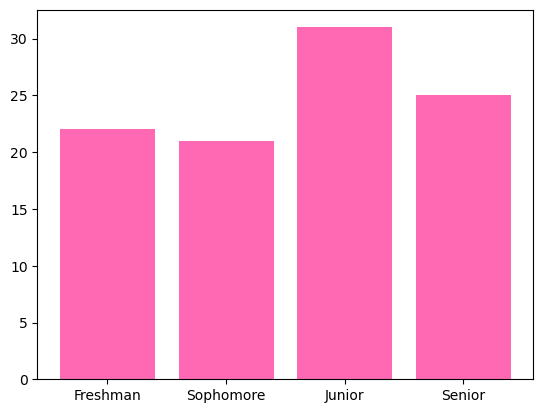

```python
categories = ["Freshman", "Sophomore", "Junior", "Senior"]

count = [22, 21, 31, 25]

plt.bar(x = categories, height = count, color = "hotpink")
plt.show()
```

#### In the cell below, a Boolean variable `is_pink` is defined. Using an if/else statement, write code that generates the bar plot with pink bars when `is_pink` is True. Otherwise, if it is `False` it should display a plot with the default color scheme, like in Lecture 6.

#### Run the code with both `is_pink = False` and `is_pink = True` to make sure it works for both cases.

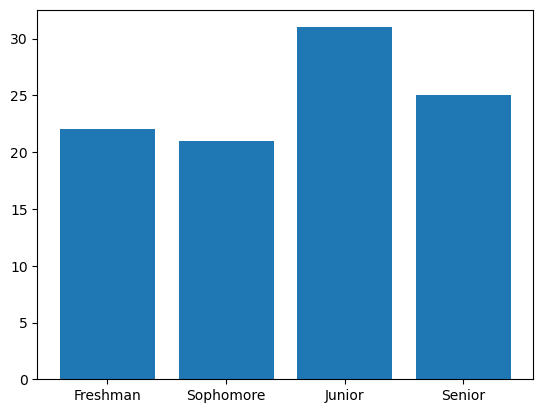

```python
is_pink = False

# SOLUTION


if is_pink:
    plt.bar(x = categories, height = count, color = "hotpink")

else:
    plt.bar(x = categories, height = count)

# Show the plot in both cases - so should be outside the if/else blocks
plt.show()
```

#### **3)** Threshold testing a sum

#### Create a numeric vector (array), $ c = \begin{bmatrix} 1 \\ 2 \\ 3 \end{bmatrix} $

#### Use the `numpy.sum()` function to add up the individual elements in the array.

#### If the sum of numbers is greater than or equal to $5$, print a message saying " The sum is greater than or equal to 5"

#### Otherwise, print the message "It is strictly less than 5"

```python
# SOLUTION

c = np.array([1, 2, 3])

c_sum = np.sum(c)

if c_sum >= 5:
    print("The sum is greater than or equal to 5")
else:
    print("It is strictly less than 5")
```

```
The sum is greater than or equal to 5
```

```python
# ANOTHER SOLUTION - skip intermediate variable

c = np.array([1, 2, 3])

if np.sum(c) >= 5:
    print("The sum is greater than or equal to 5")
else:
    print("It is strictly less than 5")
```

```
The sum is greater than or equal to 5
```

#### **4)** Write code that tests if a string is a valid password. The password must meet the following requirements:

#### It must be at least 8 characters long

#### It must have at least one non-alphabetic character (a number or a symbol)

#### If it contains letters, at least one must be uppercase

#### Write code that checks each of these requirements in order. If it fails one of the tests, it should print a message describing the issue. **It should only print a message for the first criterion it fails.** If it passes all the tests, it should print a message such as "Password set successfully" or "Valid password entered"

#### In the cell below, we demonstrate some **string methods** that will make this task easier.

```python
my_string = "Albert"
print(len(my_string)) # length
print(my_string.isalpha()) # determines if it contains only letters and numbers
print(my_string.islower()) # determines if all letters are lowercase

print()

string_2 = "peter123"
print(len(string_2))
print(string_2.isalpha())
print(string_2.islower())

print()

string_3 = "!!123"
print(len(string_3))
print(string_3.isalpha())
print(string_3.islower())
```

```
6
True
False

8
False
True

5
False
False
```

#### Complete the password check below

```python
proposed_password = "axziww"

# run this cell with each of these passwords

# proposed_password = "axziwwuv"
# proposed_password = "#axziwwuv?"
# proposed_password = "#axZiwwuv?"

# SOLUTION

if len(proposed_password) < 8:
    print("Password must contain at least 8 characters")
elif proposed_password.isalpha():
    print("Password must contain a number or a symbol")
elif proposed_password.islower():
    print("Password contains letters - at least one should be uppercase")
else:
    print("Valid password!")
```

```
Password must contain at least 8 characters
```

#### **5)** Here is another way to make a list larger using the `.append` method.

```python
my_list = [] # empty list
print(my_list)

my_list.append(1)
print(my_list)

my_list.append("abcd")
print(my_list)

my_list.append(33)
print(my_list)
```

```
[]
[1]
[1, 'abcd']
[1, 'abcd', 33]
```

#### Change the code below so that it uses `.append` instead of concatenation.

```python
# make the necessary changes below

good_movies = []
ok_movies = []
bad_movies = []

cut_off_1 = 7.0 # minimum rating for "good movie"
cut_off_2 = 6.0


title_1 = "The Umbrellas of Cherbourg"
imdb_rating_1 = 7.8

title_2 = "M3gan"
imdb_rating_2 = 6.3

title_3 = "Psycho"
imdb_rating_3 = 8.5

title_4 = "Melania"
imdb_rating_4 = 1.3

# Divide movies between the three lists
# print a warning if we encounter a bad movie

if imdb_rating_1 >= cut_off_1:
    good_movies.append(title_1)
elif imdb_rating_1 >= cut_off_2:
    ok_movies.append(title_1)
else:
    bad_movies.append(title_1)
    print("Warning! Bad movie alert:", title_1)

if imdb_rating_2 >= cut_off_1:
    good_movies.append(title_2)
elif imdb_rating_2 >= cut_off_2:
    ok_movies.append(title_2)
else:
    bad_movies.append(title_2)
    print("Warning! Bad movie alert:", title_2)


if imdb_rating_3 >= cut_off_1:
    good_movies.append(title_3)
elif imdb_rating_3 >= cut_off_2:
    ok_movies.append(title_3)
else:
    bad_movies.append(title_3)
    print("Warning! Bad movie alert:", title_3)


if imdb_rating_4 >= cut_off_1:
    good_movies.append(title_4)
elif imdb_rating_4 >= cut_off_2:
    ok_movies.append(title_4)
else:
    bad_movies.append(title_4)
    print("Warning! Bad movie alert:", title_4)


print(good_movies)
print(ok_movies)
print(bad_movies)
```

[output not shown]

#### **6)** The code cell below generates a random integer between 1 and 20 (both 1 and 20 are possible values).

#### Write code that tests the following:

#### Tests if the number satisfies $1 \leq n < 5$.

#### Tests if the number satisfies $5 \leq n \leq 10$

#### Test if the number satisfies $10 < n < 15$

#### If it satisfies one of the conditions, it prints a message saying which one. If it doesn't satisfy any of the conditions, print a statement saying the number is greater than or equal to 15.

```python
import random

lo = 1
hi = 20

random_int = random.randint(lo, hi)
print(random_int)

# SOLUTION

if 1 <= random_int < 5:
    print("In the interval [1, 5)")
elif 5 <= random_int <= 10:
    print("In the interval [5, 10]")
elif 10 < random_int < 15:
    print("In the interval (10, 15)")
else:
    print("Greater than or equal to 15")
```

```
10
In the interval [5, 10]
```

```python
# NOTE: can also use "and" here

lo = 1
hi = 20

random_int = random.randint(lo, hi)
print(random_int)

if (1 <= random_int) and (random_int < 5):
    print("In the interval [1, 5)")
elif (5 <= random_int) and (random_int <= 10):
    print("In the interval [5, 10]")
elif (10 < random_int) and (random_int < 15):
    print("In the interval (10, 15)")
else:
    print("Greater than or equal to 15")
```

```
2
In the interval [1, 5)
```

#### **8)** Repeat the same exercise above with one change: if the number doesn't pass any of the tests, no additional code should be executed.

```python
import random

lo = 1
hi = 20

random_int = random.randint(lo, hi)
print(random_int)

# SOLUTION

if 1 <= random_int < 5:
    print("In the interval [1, 5)")
elif 5 <= random_int <= 10:
    print("In the interval [5, 10]")
elif 10 < random_int < 15:
    print("In the interval (10, 15)")

# an "else" statement is NOT necessary!
```

```
17
```

#### **9)** Do the following:

#### Create a string with your first name (first letter capitalized) and save it to a variable `my_name`

#### Turn to a classmate and create a string with their first name (first letter capitalized) and save it to a variable `classmate_name`

#### Test whether or not your name is "greater than" your classmate's name. What rule do you think Python uses to determine this?

```python
# SOLUTION

my_name = "Peter"
wife_name = "Samah"

print(my_name > wife_name)

# Python uses "Lexicographical" ordering "aka" "Alphabetical" ordering.

# The ordering of letters is:
# "A" < "B" < "C" < ... < "X" < "Y" < "Z" < "a" < "b" < ... < "y" < "z"

# Since "P" < "S", it follows that "Peter" < "Samah"
# After this is determined, the letters that follow don't matter
```

```
False
```

#### **10)** Run the cell below. How do you explain the output you see?

```python
list_1 = [0, 0, 0, 0, 0]
list_2 = [5, 50, 75, 100, -0.01]
print(list_1 <= list_2)

# Explanation: This is very similar to alphabetical ordering

# If we put the words "Zebra" and "Apple" in alphabetical order, we
# would put Apple before Zebra, because A comes before Z in the alphabet.
# The endings "pple" and "ebra" do not need to be considered.

# Lists work in a similar way

# Above, since list_1[0] = 0, list_2[0] = 5, and "0 <= 5" is True,
# Python declares that the statement list_1 <= list_2 is True

# So even though list_1[4] <= list_2[4] is False,
# comparing the entire lists evaluates to True
```

```
True
```

#### **11)** Predict what the output of the cell below will be **before** running it. What is happening in the code?

```python
x = 7
y = 3

z = x*y + 9

q = z/10

x = x - q

x = x == 4

# Predict what this will print, then uncomment and run the cell to check your answer
print(x)
```

```
True
```

```python
# We will keep track of the values of each variable

# We assign 7 to "x" and assign 3 to "y"
x = 7
y = 3

# x: 7
# y: 3

# compute 7*3 + 9 = 30, and assign it to "z"
z = x*y + 9

# z: 30

# Compute 30/10 = 3 and assign it to "q"
q = z/10

# q: 3

# Compute 7 - 3 = 4 and assign it to "x", overwriting the old value of 7
x = x - q

# x: 7̶ 4

# Compare the variable x with the integer 4, using "=="
# This evaluates to True
# Then assign True to "x", overwriting the value of 4

x = x == 4

# x: 7̶ 4̶ True

print(x) # Since x is True, this will print True
```

```
True
```

#### **12)** Predict what the output of the below cell will be **before** running it.

```python
x = 0.1 + 0.1 + 0.1
y = 0.3

print(x == y)

# This will print False. This is because 0.1 and 0.3 have infinitely long binary expansions.
# So Python cannot represent these numbers exactly, and rounding error when computing x results
# in a different value than y.
```

```
False
```

#### **13)** Can you think of a better way of checking if two floating-point numbers are "equal"? Code up your approach below

#### **Answer:** It is generally not advisable to check if two floating point numbers are equal. Instead, check that the absolute value of their difference is smaller than some "tolerance" value.

$$ |x - y| < \textrm{tolerance}$$

```python
x = 0.1 + 0.1 + 0.1
y = 0.3

# SOLUTION
# Choose a tolerance of 10^(-12) = 0.000000000001
tolerance = 10**(-12)
tolerance_alternative = 1e-12 # another way of writing 10^(-12)

print(abs(x - y) < tolerance)
print(abs(x - y) < tolerance_alternative)
```

```
True
True
```